# Data analysis and visualization in R

Modulo 5 – Narrativa visual, EDA, colores y accesibilidad

Author

Albert Tafur Rangel, M.Sc, Ph.D.

# Design a data analysis and viz epidemiology project

This document integrates the conceptual, methodological, and technical competencies developed throughout the previous modules of the course. Its objective is to guide the participant through a complete and reproducible workflow for epidemiological data analysis using the R ecosystem. The material covers the sequential stages of a rigorous analytic pipeline, including data importation, inspection of data structures, cleaning and harmonization, exploratory analysis, generation of summary statistics, identification of anomalies, and the construction of visualizations that support analytical reasoning and evidence-based interpretation. Emphasis is placed on the design of effective figures, the evaluation of alternative graphical encodings, and the application of accessibility principles such as perceptually uniform color palettes and color-blind-safe schemes.

## Load the libraries

The analytical workflow begins with the configuration of a coherent and reproducible working environment in R. This step ensures that all required packages are available, loaded, and functioning correctly before any data manipulation or visualization is performed. Establishing a well-defined environment is essential for ensuring consistency across analyses, facilitating collaboration, and preventing errors arising from version incompatibilities or missing dependencies.

In this module, we rely on a set of packages from the *tidyverse* ecosystem to manage data structures, perform transformations, and construct statistical graphics under a unified grammar. Additional libraries support tasks related to data cleaning, date handling, accessibility evaluation, and the implementation of perceptually uniform color scales—elements fundamental for producing rigorous and reproducible epidemiological visualizations.

Before loading the packages, it is important to verify that they are installed in your local R environment. If a package is missing, it can be installed using the following general syntax:

install.packages(“package_name”)

For example, to install the *tidyverse*:

install.packages(“tidyverse”)

Once all required packages are installed, they can be loaded as follows:

```r
# Core data science ecosystem
library(tidyverse)      # Data manipulation, summarization, ggplot2
library(janitor)        # Data cleaning, variable standardization
library(lubridate)      # Date and time parsing
library(readxl)         # Importing Excel datasets

# Visualization and color management
library(colorspace)     # Perceptually uniform palettes
library(colorblindcheck) # Accessibility diagnostics for color palettes
library(scales)         # Formatting axes, labels, and scales
library(patchwork)

# Additional utilities
library(knitr)          # Reporting utilities in Quarto/R Markdown
```

Once the environment has been initialized, participants should confirm that their working directory is correctly set and that the local structure of files is organized to support reproducibility. This includes ensuring that datasets, scripts, and outputs (figures, tables, and derived data) are stored in appropriately labeled folders. A disciplined setup at this stage provides a solid foundation for the subsequent stages of epidemiological data analysis.

A well-organized directory structure is fundamental for ensuring reproducibility, transparency, and efficient collaboration in data-driven epidemiological analyses. As a recommended practice, each project should be contained within a dedicated folder named according to the study or initiative—for example, `ASIS`. Within this main directory, it is advisable to create a set of subfolders that separate code, data, and analytical outputs. A common and effective structure includes:

- `code/` — scripts used for importing, cleaning, transforming, and analyzing the data.
- `data/`
  - `raw/` — original datasets stored exactly as received, without modifications.
  - `processed/` — cleaned, harmonized, or transformed datasets generated during the analysis.
- `results/`
  - `figures/` — visualizations produced during the exploratory and inferential steps.
  - `tables/` — summary statistics, model outputs, and tabulated results.

This hierarchical organization facilitates traceability, prevents accidental overwriting of original data, and supports a seamless workflow when producing reproducible reports with Quarto. It also enables clear version control and easier communication of analytic decisions during collaborative work or peer review.

## Color Definitions and Principles for Consistent Use

A coherent and well-documented color strategy is essential for producing visualizations that are accurate, accessible, and interpretable in epidemiological contexts. Color must not serve merely as decoration; it functions as a perceptual encoding that guides attention, emphasizes contrasts, and supports analytical reasoning. For this reason, we adopt a structured set of palettes—sequential, diverging, and qualitative—each selected according to the type and scale of the variable being represented. All palettes included are perceptually uniform or color-blind-safe, ensuring accessibility and consistency throughout the analytical workflow.

### Sequential Palettes

Sequential palettes are appropriate for variables measured on a continuous scale and where magnitude carries interpretive meaning, such as incidence rates, temperature, rainfall, or risk scores. These palettes encode increasing intensity through a smooth progression of luminance.

**TipRecommended options:**

```r
pal_seq_viridis <- colorspace::sequential_hcl(7, palette = "Viridis")

pal_seq_blues <- colorspace::sequential_hcl(7, palette = "Blues")

pal_seq_magma <- colorspace::sequential_hcl(7, palette = "Inferno")
```

**Use when:**

- Representing epidemiological counts or rates.
- Mapping gradients in heatmaps, temporal trends, or geospatial incidence surfaces.
- Emphasizing low-to-high transitions without categorical breaks.

### Diverging Palettes

Diverging palettes are intended for variables with a meaningful central reference point—for example, deviations from baseline, anomalies relative to average temperature, percent change, or differences before and after an intervention. These palettes emphasize both directionality and magnitude.

**TipRecommended options:**

```r
pal_div_blue_red <- colorspace::diverging_hcl(9, palette = "Blue-Red 3")

pal_div_green_brown <- colorspace::diverging_hcl(9, palette = "Green-Brown")
```

**Use when:**

- Comparing increases vs. decreases in incidence.
- Visualizing residuals, standardized differences, or temporal anomalies.
- Communicating values on both sides of a reference threshold.

### Qualitative Palettes

Qualitative palettes are suitable for categorical variables with no intrinsic order, such as regions, municipalities, vector species, or diagnostic categories. Colors must be distinguishable and carry equal perceptual weight.

**TipRecommended options:**

```r
pal_qual_dark3 <- colorspace::qualitative_hcl(8, palette = "Dark 3")

pal_qual_set2 <- colorspace::qualitative_hcl(8, palette = "Set 2")

pal_qual_rainbow <- colorspace::qualitative_hcl(8, palette = "Harmonic")
```

**Use when:**

- Visualizing multiple administrative units.
- Differentiating categories with similar epidemiological importance.
- Avoiding perceptual hierarchies where no order is intended.

### Special Palette for Sex-Stratified Comparisons

Epidemiological analyses frequently require comparison between men and women. The use of culturally ambiguous or stereotypical colors is discouraged; instead, we apply a palette that is perceptually balanced, color-blind-safe, and maintains clear contrast between groups.

**TipRecommended options:**

```r
pal_sex <- c(
    "Women" = "#0072B2", # Blue (accessible, stable across palettes)
    "Men" = "#D55E00" # Vermilion (high contrast, CVD-safe)
 )
```

**Justification:**

- Both colors come from the scientific color palette of *Okabe & Ito*, designed for color-blind accessibility.
- The pair exhibits high luminance contrast, ensuring readability in lines, points, and bars.
- It avoids cultural pink/blue stereotypes while remaining intuitive in analytic presentations.

### Color-Accessibility Diagnostics

Ensuring that visualizations are accessible to individuals with color-vision deficiencies (CVD) is a central requirement for scientific communication. Epidemiological analyses frequently inform decision-making among diverse audiences, including public health officials, clinicians, researchers, and community stakeholders. Consequently, all visual encodings must remain interpretable under common forms of color-blindness such as protanopia, deuteranopia, and tritanopia.

To support accessibility, we incorporate systematic diagnostic tools provided by the **colorblindcheck** package. This package simulates how plots appear under different CVD conditions and evaluates whether the chosen palette preserves sufficient perceptual contrast. These diagnostics should be applied before adopting any palette in recurrent analyses or final reporting.

The following example shows how to evaluate the palette defined for sex-stratified comparisons:

```r
# Evaluate perceptual distinguishability of the sex palette
colorblindcheck::palette_check(pal_sex)
```

```
          name n tolerance ncp ndcp min_dist mean_dist max_dist
1       normal 2  49.62426   1    1 49.62426  49.62426 49.62426
2 deuteranopia 2  49.62426   1    1 56.51415  56.51415 56.51415
3   protanopia 2  49.62426   1    1 49.98621  49.98621 49.98621
4   tritanopia 2  49.62426   1    1 54.57325  54.57325 54.57325
```

**NoteCheck**

Example:

```r
set.seed(123)

# Crear secuencia de fechas (12 semanas)
fechas <- seq.Date(from = as.Date("2023-01-01"),
                   by   = "week",
                   length.out = 12)

# Generar datos simulados de casos por sexo
datos <- tibble(
  fecha = rep(fechas, times = 2),
  sexo  = rep(c("Women", "Men"), each = length(fechas)),
  casos = c(
    # Mujeres: tendencia suave con fluctuación
    round(runif(12, min = 20, max = 60) + seq(0, 11)*1.5),
    # Hombres: valores ligeramente superiores y con más variabilidad
    round(runif(12, min = 30, max = 75) + seq(0, 11)*2)
  )
)

p <- datos |>
  ggplot(aes(fecha, casos, color = sexo)) +
  geom_line(linewidth = 1.2) +
  scale_color_manual(values = pal_sex) +
  labs(
    title = "Incidencia de dengue",
    x = "Semana epidemiológica",
    y = "Número de casos") +
  theme_minimal(base_size = 13)

# Generate a 4-panel simulation of color-vision variations
pal_sex_deutan <- deutan(pal_sex)
pal_sex_protan <- protan(pal_sex)
pal_sex_tritan <- tritan(pal_sex)

# show results
list(
  original = pal_sex,
  deutan = pal_sex_deutan,
  protan = pal_sex_protan,
  tritan = pal_sex_tritan
)

p1 <- p

p2 <- p +
  scale_color_manual(values = pal_sex_deutan) +
  labs(title = "Deuteranopia")

p3 <- p +
  scale_color_manual(values = pal_sex_protan) +
  labs(title = "Protanopia")

p4 <- p +
  scale_color_manual(values = pal_sex_tritan) +
  labs(title = "Tritanopia")
```

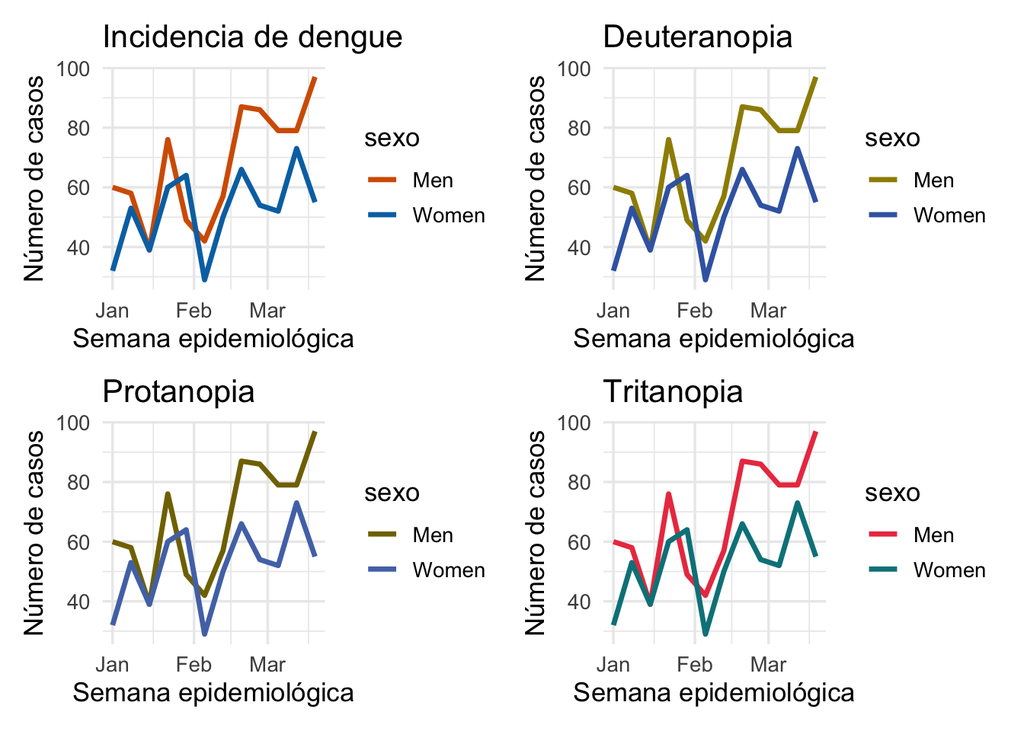

```r
# Mostrar comparación
(p1 | p2) /
(p3 | p4)
```

The resulting panel helps determine whether line overlap or insufficient contrast could obscure epidemiological patterns for color-blind readers.

Sequential and diverging palettes also require diagnostic evaluation, especially when used in heatmaps or geospatial gradients where subtle hue variations carry meaningful information.

**ImportantGood Practices for Accessibly Designed Figures**

To ensure consistent accessibility across all visualizations:

- Prefer palettes derived from perceptually uniform color spaces (e.g., CIELAB, HCL).
- Avoid relying solely on color to encode meaning; incorporate line types, shapes, or annotations when appropriate.
- Ensure minimum contrast ratios between adjacent colors or classes.
- Test all finalized figures with `cvd_grid()` prior to publication or dissemination.

By incorporating these diagnostics directly into the analytical workflow, the integrity and inclusiveness of data communication in epidemiological studies are strengthened, promoting clearer interpretation and equitable access to information.

## Read the data

First download all the datasets to work in this module https://github.com/ae-tafur/data_visualization/tree/main/05_projects/excercises/data

```r
base_url <- "https://raw.githubusercontent.com/ae-tafur/data_visualization/main"

data <- read.csv(file.path(base_url,
                      "01_fundamentals/excercises/data/example_data.csv"))
```

Now explore the data

```r
data
```

```
  Grupo.de.edad..años. Infecciones.respiratorias Enfermedades.diarreicas
1                    0                        48                      32
2                    1                        55                      28
3                    2                        42                      25
4                    3                        38                      22
5                    4                        36                      18
  Enfermedades.eruptivas
1                     15
2                     18
3                     20
4                     12
5                     13
```

Check statistics

```r
summary(data)
```

```
 Grupo.de.edad..años. Infecciones.respiratorias Enfermedades.diarreicas
 Min.   :0            Min.   :36.0              Min.   :18
 1st Qu.:1            1st Qu.:38.0              1st Qu.:22
 Median :2            Median :42.0              Median :25
 Mean   :2            Mean   :43.8              Mean   :25
 3rd Qu.:3            3rd Qu.:48.0              3rd Qu.:28
 Max.   :4            Max.   :55.0              Max.   :32
 Enfermedades.eruptivas
 Min.   :12.0
 1st Qu.:13.0
 Median :15.0
 Mean   :15.6
 3rd Qu.:18.0
 Max.   :20.0
```

Select a plot and create one. Here is the code that we have been working on, use it.

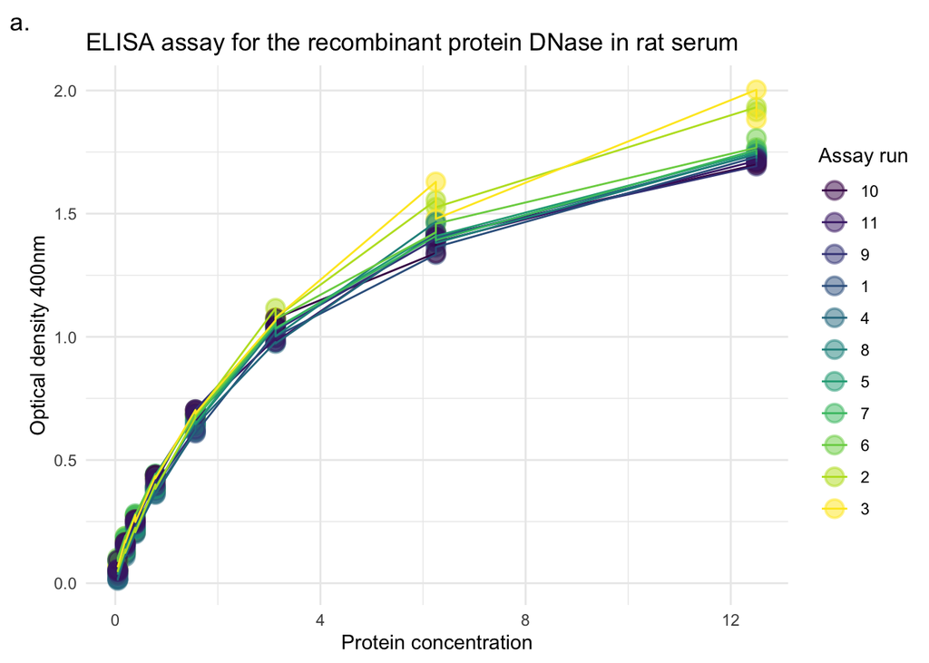

```r
ggplot(data = DNase) +
  aes(x = conc,
      y = density,
      color = Run) +
  geom_point(alpha = .5,
             # shape = "x",
             stroke = 1,
             size = 4) +
  geom_line() +
  labs(x = "Protein concentration",
       y = "Optical density 400nm",
       title = "ELISA assay for the recombinant protein DNase in rat serum",
       color = "Assay run",
       tag = "a.") +
  theme_minimal()
```